# Lesson 4: Metropolis-Hastings

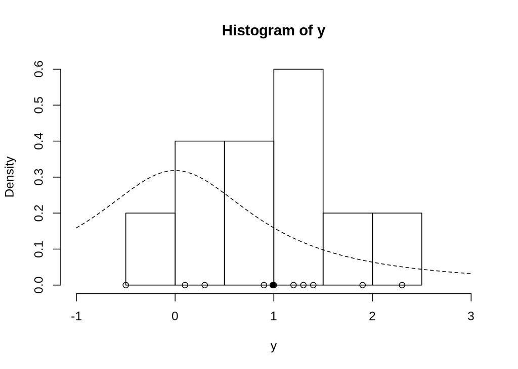

```r
y = c(1.2, 1.4, -0.5, 0.3, 0.9, 2.3, 1.0, 0.1, 1.3, 1.9)
ybar = mean(y)
n = length(y)
hist(y, freq=FALSE, xlim=c(-1.0, 3.0)) # histogram of the data
curve(dt(x=x, df=1), lty=2, add=TRUE) # prior for mu (x=x on argumendi puudumine pmtslt, annab generic jaotuse)
points(y, rep(0,n), pch=1) # individual data points
points(ybar, 0, pch=19) # sample mean
```

Viimaks jooksutame sämplerit. Kasutame m = 1000 iteratsiooni ja *proposal* standard deviationi (mis hoiab *proposal* step size’i kontrolli all) 3.0, ja algset väärtust eeljaotuse mediaai 0 juures.

```r
set.seed(43) # set the random seed for reproducibility
post = mh(n=n, ybar=ybar, n_iter=1e3, mu_init=0.0, cand_sd=3.0) #anname üleval loodud funktsioonile argumendid
str(post) #annab objekti (siinkohal list) sees olevad andmed
```

```
## List of 2
##  $ mu   : num [1:1000] -0.113 1.507 1.507 1.507 1.507 ...
##  $ accpt: num 0.122
```

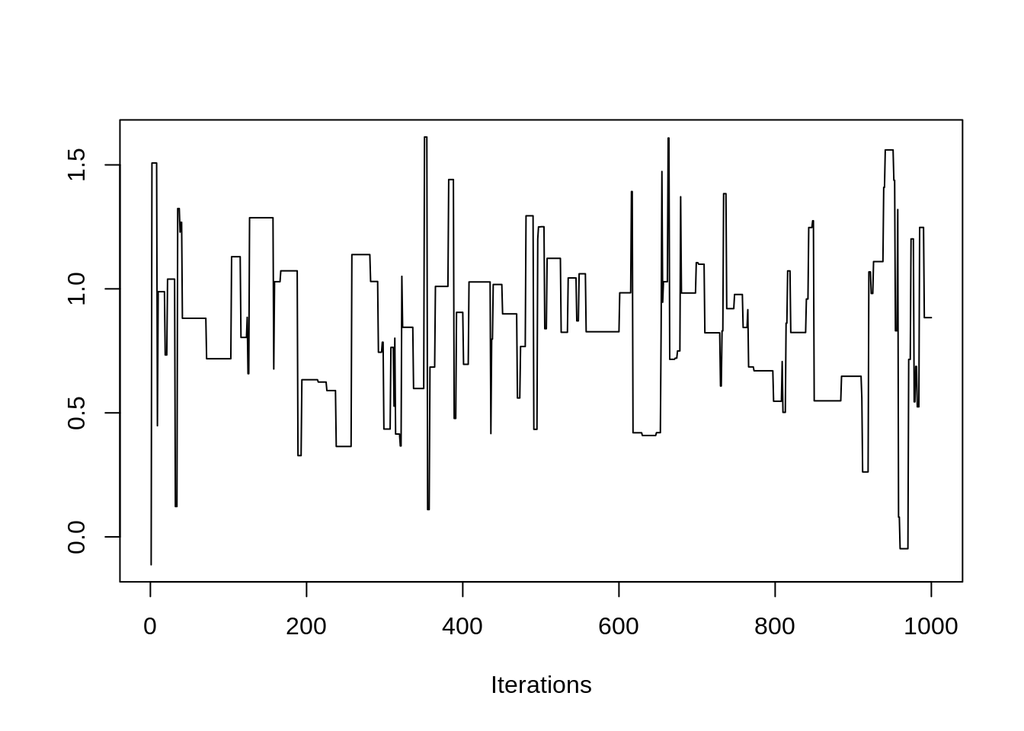

```r
library("coda")
traceplot(as.mcmc(post$mu)) #peame post muutuja tegema mcmc objektiks
```

See plot on **trace plot** ja näitab markovi ahela ajalugu ja annab *feedbacki **selle kohta, kas ahel on jõudnud oma** statsionaarsesse jaotusesse**.

Tundub, et meie *proposal step* oli liiga suur (vastuvõtmise suhteline sagedus on alla 23%, mis on näha post listis salvestatud accpt rate = 12.2%). Step tuleb sellest, kuidas määrame meie *proposal jaotuse* standardhälbe. Arvan ise, et kui standardhälve on suur, siis on soovitatud $\mu$ väärtuste “tõenäosuste” (g() jaotuses) suhe liiga tihti üle ühe ja samal ajal on ka liiga tihti vahe praeguse ja kandidaat $\mu$ tõenäosuse (g() funktsiooni järgse) vahel nii suur, et alpha ehk vastu võtmise % ehk *acceptance rate* on madal (näha ka, et $\mu$ väärtus jääb pikalt samaks mingites vahemikes, kus on flat joon). Seega proovime teistsugust proposal jaotuse standardhälvet.

```r
post = mh(n=n, ybar=ybar, n_iter=1e3, mu_init=0.0, cand_sd=0.05)
post$accpt
```

```
## [1] 0.946
```

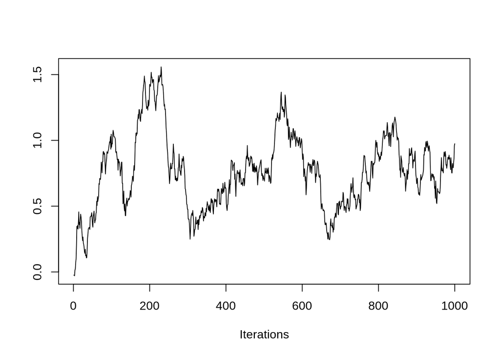

```r
traceplot(as.mcmc(post$mu))
```

Nüüd on vastuvõtmise suhteline sagedus liiga kõrge (üle 50%). Proovime nüüd midagi vahepealset. Eesmärk on Random-Walk Metropolis hastingi puhul 23%-50%

```r
post = mh(n=n, ybar=ybar, n_iter=1e3, mu_init=0.0, cand_sd=0.9)
post$accpt
```

```
## [1] 0.38
```

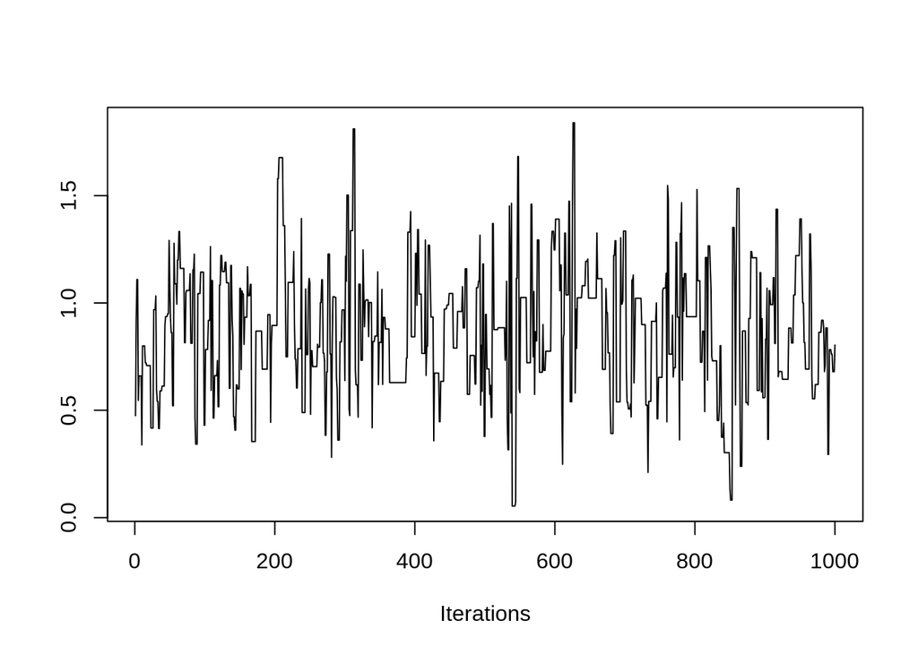

```r
traceplot(as.mcmc(post$mu))
```

See tundub päris hea. Lihtsalt lõbu pärast vaatame, mis saab kui alustame ahelat mingist väga kaugest väärtusest

```r
post = mh(n=n, ybar=ybar, n_iter=1e3, mu_init=30.0, cand_sd=0.9)
post$accpt
```

```
## [1] 0.387
```

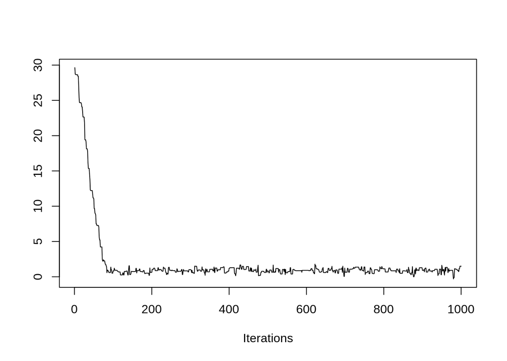

```r
traceplot(as.mcmc(post$mu))
```

Nagu näha siin üleval, läks aega, et leida **statsionaarne jaotus**, aga me jõudsime selleni. Kui me jätame esimsed 100 vms väärtust välja, siis tundub, et ülejäänud valimid tulevad statsionaarsest jaotusest ehk meie **järeljaotusest**!!!

Nüüd paneme graafikule järeljaotuse tiheduse ja eeljaotuse, et näha, kuidas andmed meie uskumusi $\mu$ kohta muutsid

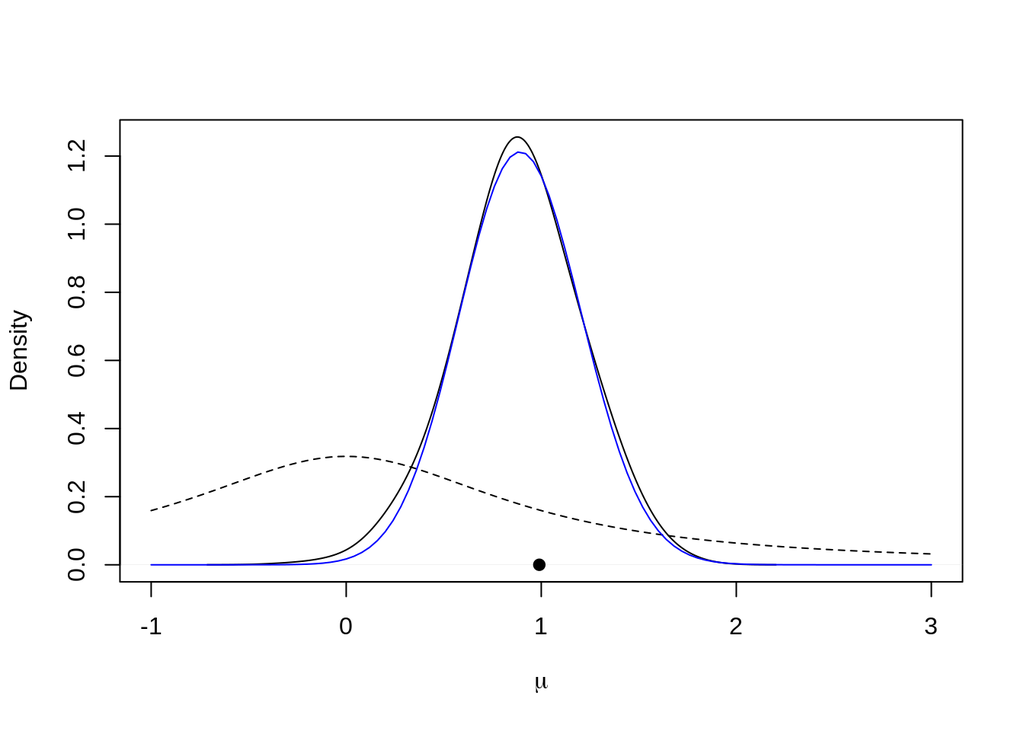

```r
post$mu_keep = post$mu[-c(1:100)] # discard the first 100 samples ja lisama oma post listi uue objekti mu_keep
plot(density(post$mu_keep, adjust=2.0), main="", xlim=c(-1.0, 3.0), xlab=expression(mu)) # plot density estimate of the posterior
curve(dt(x=x, df=1), lty=2, add=TRUE) # prior for mu
points(ybar, 0, pch=19) # sample mean

curve(0.017*exp(lg(mu=x, n=n, ybar=ybar)), from=-1.0, to=3.0, add=TRUE, col="blue") # approximation to the true posterior in blue
```

Siin plotil on must joon keskmisega, kus meie 0.9 proposal sd-ga Hastings algoritm convergeis ja on näha ,et algoritmist saadud $\mu$ väärtused on enamasti selle convergeimis punkti ümber suuremas osas. Seega simuleeriski algoritm (mille proposal jaotus tekitab convergence’it selliselt, et saadav jaotus jääks andmete ja priori vahele) meile post listis asuva $\mu$ väärtuste vektori, mis defineerib posterior jaotuse, mis põhineb andmetel ja prioril.

Need tulemused on julgustavad, kuid väga algsed. Me peame siiski veel formaalselt uurima, kas meie Markovi ahel on jõudnud statsionaarsesse jaotusesse. Seda uurime järgmistes osades.

Metropolis-Hastingsi kasutamine valimite saamiseks võtab aega ja nõuab peenhäälestust nagu me nägime. Hea on see, et me saame lasta tarkvaral enamus tööd ära teha. Järgmistest videotes kasutame programmi, mis teeb järeljaotustest valimite võtmise kergeks.